Pablo X Zumba | Data Engineer

pzumbap@gmail.com | (352)470-7012

Portfolio Project using Python with Jupyter Lab

# Life expectancy and GDP Project

The purpose of this project is to investigate the relationship between life expectancy and Gross Domestic Product (GDP) in six countries strategically selected to represent diversity in the world. Five key questions will be answered to see that relationship.

## Scoping Project

```
1) Has life expectancy increased over time in the six nations?
2) Has GDP increased over time in the six nations?
3) Is there a correlation between GDP and life expectancy of a country?
4) What is the average life expactancy in these nations?
5) What is the distribution of that life expectancy?
```

## Loading Data

```python
import pandas as pd
from matplotlib import pyplot as plt
from numpy import mean
import seaborn as sns
```

```python
all_countries = pd.read_csv('all_data.csv')
#print(all_countries.head(), all_countries.info())
#Seems like the third column name are very descriptive but not usefull to use in programming.
all_countries.rename(columns={'Life expectancy at birth (years)': 'LEABY'}, inplace=True)
#print(all_countries.head(), all_countries.info())
```

## 1) Has life expectancy increased over time in the six nations? 2) Has GDP increased over time in the six nations?

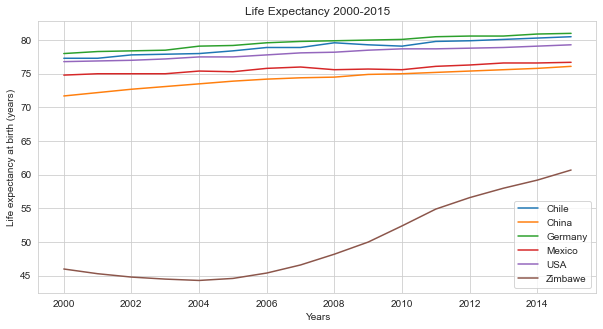

```python
name_countries = ['Chile', 'China', 'Germany', 'Mexico', 'USA', 'Zimbawe']

ax1 = sns.set_style('whitegrid')
ax1 = plt.subplots(figsize=(10, 5))
sns.lineplot(data=all_countries, x="Year", y="LEABY", hue='Country')
plt.title('Life Expectancy 2000-2015')
plt.xlabel('Years')
plt.ylabel('Life expectancy at birth (years)')
plt.legend(name_countries, loc=4)
plt.savefig('Life_Expectancy1.png')
plt.show()
```

The graph shows that life expectancy increases in all countries, but Zimbabwe's increase is more significant than others.

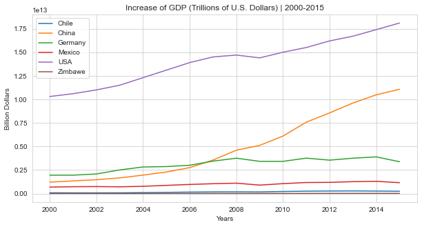

```python
ax2 = sns.set_style('whitegrid')
ax1 = plt.subplots(figsize=(10, 5))
sns.lineplot(data=all_countries, x="Year", y="GDP", hue='Country')
plt.title('Increase of GDP (Trillions of U.S. Dollars) | 2000-2015')
plt.xlabel('Years')
plt.ylabel('Billion Dollars')
plt.legend(name_countries, loc=2)

plt.savefig('GDP_only.png')
plt.show()
```

Based on the second graph, we can see that the USA and China have higher GDPs than other countries. The US GDP decreased slightly in 2009 due to the recession but immediately began to increase again in 2010. As compared to all other countries, China's GDP has increased significantly without downfalls, and Germany's has fluctuated slowly over time.

## 3) Is there a correlation between GDP and life expectancy of a country?

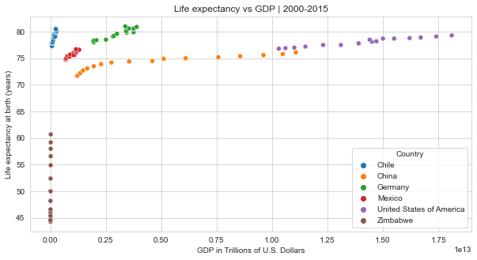

```python
plt.clf()

ax1 = plt.subplots(figsize=(10, 5))
ax1 = sns.set_style('whitegrid')
sns.scatterplot(data=all_countries, x="GDP", y="LEABY", hue='Country')
plt.title('Life expectancy vs GDP | 2000-2015')
plt.xlabel('GDP in Trillions of U.S. Dollars')
plt.ylabel('Life expectancy at birth (years)')

plt.savefig('LEABY_vs_GDPscatterplot.png')
plt.show()
```

## 4) What is the average life expactancy in these nations?

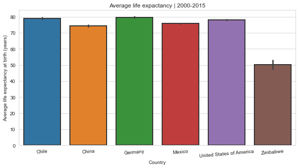

```python
plt.clf()

ax1 = plt.subplots(figsize=(10, 5))
ax1 = sns.set_style('whitegrid')
sns.barplot(data=all_countries, x="Country", y="LEABY", estimator=mean, linewidth=2, edgecolor=".2")
plt.xticks(rotation=5)
plt.title('Average life expactancy | 2000-2015')
plt.xlabel('Country')
plt.ylabel('Average life expectancy at birth (years)')

plt.savefig('AverageLifeExpectancy.png')
plt.show()
```

In this graph we can see cleary that the average life expectancy of Chile, China, Germany, Mexico and USA are between the age of 73 and 80. Only Zimbawe is far behind from them with an average life expectancy of 50 years old. Notice that the error bar of Zimbawe is big compared to the other countries; this is because the high variation of life expectancy over the years.

## 5) What is the distribution of that life expectancy?

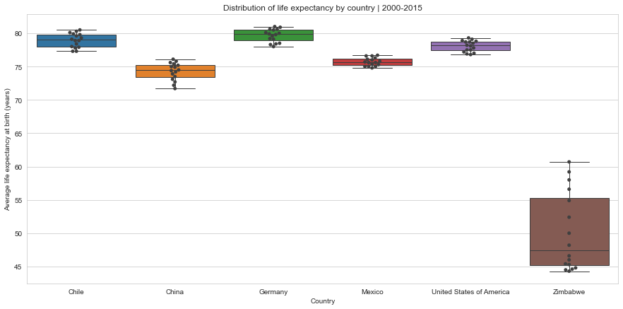

```python
plt.clf()

ax1 = plt.subplots(figsize=(15, 7))
ax1 = sns.set_style('darkgrid')
sns.boxplot(data=all_countries, x="Country", y="LEABY", linewidth=1)
sns.swarmplot(data=all_countries, x="Country", y="LEABY", color="0.25")
plt.title('Distribution of life expectancy by country | 2000-2015')
plt.xlabel('Country')
plt.ylabel('Average life expectancy at birth (years)')

plt.savefig('AverageLifeExpectancy.png')
plt.show()
```

Although Chile and Germany have lower GDPs than the United States and China, they have higher life expectancies. Due to its narrow distribution, Mexico's life expectancy has remained almost the same over the years, while Zimbabwe's has a significant distribution that explains the length of the error bar in the previous graph.

# Conclusions